# Lab 15 - Introduction to Reccurent Neural Networks

This lab will cover a few basic implementations of reccurrent neural networks in `torch` for an application where the data are the surnames of a sample of individuals for six different nationalities.

To begin, you'll need to import the following libraries:

```python
import torch
import torchvision
import string
```

Next, the data used throughout the lab is stored in a zipped folder available here:

- https://remiller1450.github.io/data/surnames.zip

This folder contains 6 different text files, one per nationality, that are list of unique surnames observed among the members of that nationality (with one name per line). After modifying the root path, you may use the following code to load the information in these textfiles into Python lists:

```python
root = 'C:/Users/millerry/OneDrive - Grinnell College/Documents/surnames/'
Chinese = open(root+'Chinese.txt', encoding='utf-8').read().strip().split('\n')
Japanese = open(root+'Japanese.txt', encoding='utf-8').read().strip().split('\n')
Korean = open(root+'Korean.txt', encoding='utf-8').read().strip().split('\n')
English = open(root+'English.txt', encoding='utf-8').read().strip().split('\n')
Irish = open(root+'Irish.txt', encoding='utf-8').read().strip().split('\n')
Russian = open(root+'Russian.txt', encoding='utf-8').read().strip().split('\n')
```

### Part 1 - Data Preparation

Recurrent neural networks are designed to work sequential data, and our models throughout the lab will consider each character within a name as a sequential observation. This framework requires us to represent the individual characters in a name using a one-hot vectors.

To facilitate this process, we'll start by defining a helper function that converts a single line of text (name) into a tensor that contains one-hot vectors representing each character.

```python
## We'll consider all ascii letters plus basic punctuation
all_letters = string.ascii_letters + " .,;'"
n_letters = len(all_letters)

## Function to iterate through a line of text encode each letter as a 1 x 57 vector in an nchar x 1 x 57 tensor
def nameToTensor(line):
    tensor = torch.zeros(len(line), 1, n_letters)
    for li, letter in enumerate(line):
        tensor[li][0][all_letters.find(letter)] = 1
    return tensor
```

The code below demonstrates the behavior of this function on a simple example, the line "Aa". Notice that the output is a tensor with dimensions [2, 1, 57].

```python
## Demonstration of the test name "Aa", notice the "A" is encoded as the 27th position, and "a" is the 1st position
example = nameToTensor('Aa')
print(example)

## Also notice dim1 of the tensor is the number of charactersr in the name
print(example.size())
```

```
tensor([[[0., 0., 0., 0., 0., 0., 0., 0., 0., 0., 0., 0., 0., 0., 0., 0., 0.,
          0., 0., 0., 0., 0., 0., 0., 0., 0., 1., 0., 0., 0., 0., 0., 0., 0.,
          0., 0., 0., 0., 0., 0., 0., 0., 0., 0., 0., 0., 0., 0., 0., 0., 0.,
          0., 0., 0., 0., 0., 0.]],

        [[1., 0., 0., 0., 0., 0., 0., 0., 0., 0., 0., 0., 0., 0., 0., 0., 0.,
          0., 0., 0., 0., 0., 0., 0., 0., 0., 0., 0., 0., 0., 0., 0., 0., 0.,
          0., 0., 0., 0., 0., 0., 0., 0., 0., 0., 0., 0., 0., 0., 0., 0., 0.,
          0., 0., 0., 0., 0., 0.]]])
torch.Size([2, 1, 57])
```

**Question #1**:

- **Part A** - What is represented by the *first dimension* of the tensor produced by our `nameToTensor` function? Will the size/length of this dimension change if a different input is provided?
- **Part B** - What is represented by the *third dimension* of the tensor produced by our `nameToTensor` function? Will the size/length of this dimension change if a different input is provided?

### Part 2 - Model Architecture

Next, we'll define a network architecture to model our sequential data. We should notice that this network architecture will be flexible enough to handle inputs of different sizes (since each surname is a different length).

```python
from torch import nn
class my_rnn(nn.Module):

    ## Constructor commands
    def __init__(self, input_size, hidden_size, output_size):
        super(my_rnn, self).__init__()

        self.hidden_size = hidden_size
        self.i2h = nn.Linear(input_size + hidden_size, hidden_size)
        self.i2o = nn.Linear(hidden_size, output_size)
        self.softmax = nn.LogSoftmax(dim=1)

    ## Function to generate predictions
    def forward(self, input, hidden):
        combined = torch.cat((input, hidden), 1)
        hidden = self.i2h(combined)
        output = self.i2o(hidden)
        output = self.softmax(output)
        return output, hidden

    def initHidden(self):
        return torch.zeros(1, self.hidden_size)
```

The architecture is best understood by it's `forward` method. Here, the current input and hidden state are combined into a single tensor, named `combined`, by concatenating them along `dim = 1`. This combined tensor is used as the input to `i2h`, which produces the next hidden state. The updated hidden state is then used to produce an output, which is transformed via softmax before it is returned.

Another thing to notice is that the size of the hidden state is the only piece of this network's architecture that we might consider manipulating. Increasing the hidden size will provide the model with more flexibility to learn sequential patterns that exist within the training sequences (names), but too much flexibility could lead to overfitting.

To explore how this model works, let's initialize it with randomly generated weights and see what it outputs for an example name:

```python
## Initialize model with random weights
rnn = my_rnn(n_letters, 100, 6)

## Format an example input name (Albert)
test_input = nameToTensor('Albert')

## Provide an initial hidden state (all zeros this time)
hidden = torch.zeros(1, 100)

## Generate output from the RNN
output, next_hidden = rnn(test_input[0], hidden)
print(output)
```

```
tensor([[-1.9418, -1.7182, -1.7637, -1.8522, -1.7645, -1.7283]],
       grad_fn=<LogSoftmaxBackward0>)
```

```python
## Print the top category (predicted class)
output.topk(1)
```

```
torch.return_types.topk(
values=tensor([[-1.7182]], grad_fn=<TopkBackward0>),
indices=tensor([[1]]))
```

**Question #2**:

- **Part A** - In the given example, `my_rnn` was initialized with a value of 6 for `output_size`. Where did this value come from? Is it something you can change when tuning the network's architecture? Briefly explain.
- **Part B** - In the given example, `my_rnn` was initialized with a value of 100 for `hidden_size`. Where did this value come from? Is it something you can change when tuning the network's architecture? Briefly explain.

### Part 3 - Training

In order to train the model, we'll define the category labels and a dictionary that links our lists of names to each label.

```python
## List of categories
category_labels = ['Chinese', 'Japanese', 'Korean', 'English', 'Irish', 'Russian']

## Dictionary of categories and names
category_lines = {'Chinese': Chinese,
                 'Japanese': Japanese,
                 'Korean': Korean,
                 'English': English,
                 'Irish': Irish,
                 'Russian': Russian}
```

Next, we'll aim to train our network by feeding it randomly selected example names and updating the network's weights and biases using back-propogation.

The function defined below will help facilitate the selection of randomly chosen input names during model training:

```python
## Function to randomly sample a single example
import random
def randomTrainingExample():
    ## Randomly choose a category index (ie: Chinese, etc.)
    category = category_labels[random.randint(0, len(category_labels)-1)]

    ## Randomly choose a name in that category
    name = category_lines[category][random.randint(0, len(category_lines[category])-1)]

    ## Convert the chosen example to a tensor
    category_tensor = torch.tensor([category_labels.index(category)], dtype=torch.long)
    line_tensor = nameToTensor(name)

    return category, name, category_tensor, line_tensor

## Try it out
randomTrainingExample()
```

[output not shown]

Next, we'll set up another function to update the network's parameters after encountering a randomly selected training example:

```python
## Set learning rate
learning_rate = 0.005

## Define cost func
cost_fn = nn.CrossEntropyLoss()

## Training function for a single input (name category, name)
def train(category_tensor, line_tensor):

    ## initialize the hidden state
    hidden = rnn.initHidden()

    ## set the gradient to zero
    rnn.zero_grad()

    ## loop through the letters in the input, getting a prediction and new hidden state each time
    for i in range(line_tensor.size()[0]):
        output, hidden = rnn(line_tensor[i], hidden)

    ## Calculate cost and gradients
    cost = cost_fn(output, category_tensor)
    cost.backward()

    # Update parameters
    for p in rnn.parameters():
        p.data.add_(p.grad.data, alpha = -learning_rate) ## This adds the LR times the gradient to each parameter

    ## Return the output and cost
    return output, cost.item()
```

**Question #3**: Note that the `train` function defined above contains a for loop that iterates through the first dimension of the input line tensor (which is the tensor storing the input name).

- **Part A** - In specific terms, what is being input to the model at each iteration of this loop?
- **Part B** - In specific terms, what is being output from the model at each iteration of this loop?
- **Part C** - Notice how `hidden` is initialized (ie: reset) every time `train` is called on a new training example. What is the purpose of this step? Briefly explain.

Finally, we'll ready to train our model. We'll do this by repeatedly providing a randomly chosen name to the `train` function and tracking the acculumated cost (per 25 iterations).

```python
## Initializations
n_iters = 10000
cost_every_n = 25
current_cost = 0
track_cost = []

### Iteratively update model from randomly chosen example
for iter in range(1, n_iters + 1):
    category, line, category_tensor, line_tensor = randomTrainingExample()
    output, cost = train(category_tensor, line_tensor)
    current_cost += cost

    # Save cost every 25 iterations
    if iter % cost_every_n == 0:
        track_cost.append(current_cost/cost_every_n)
        current_cost = 0
```

Next, we'll graph the costs throughout the training process to see if our model has learned anything from our training examples:

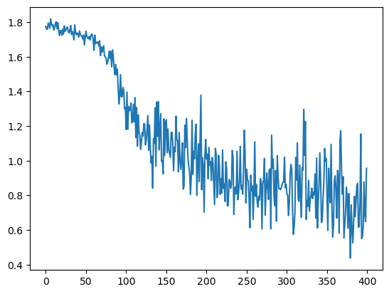

```python
import matplotlib.pyplot as plt
plt.plot(track_cost)
plt.show()
```

From this graph, we can see that the model has found some patterns within surnames. In the next section we'll explore these further by using the trained model to make predictions.

### Part 4 - Using the Model

The RNN we built and trained is designed to predict the labels of input sequences of characters. This means that we can give the trained model any valid sequence of characters and it will predict the nationality it believes that name belongs to.

To see this in action, we'll create a `predict` function that returns the top N predicted labels (and their associated outputs) for a given input name:

```python
def predict(input_line, n_predictions=4):
    print('\n> %s' % input_line)

    ## Don't update gradient with any of these examples
    with torch.no_grad():

        ## Initialize new hidden state
        hidden = rnn.initHidden()

        ## Convert input str to tensor
        input_t = nameToTensor(input_line)

        ## Pass each character into `rnn`
        for i in range(input_t.size()[0]):
            output, hidden = rnn(input_t[i], hidden)

        # Get top N categories from output
        topv, topi = output.topk(n_predictions, 1, True)
        predictions = []

        ## Go through the category predictions and save info for printing
        for i in range(n_predictions):
            value = topv[0][i].item()
            category_index = topi[0][i].item()
            print('(%.2f) %s' % (value, category_labels[category_index]))
            predictions.append([value, category_labels[category_index]])

## Try it out on a few examples:
predict('Dovesky')
predict('Miller')
predict('Satoshi')
predict('ABCDEFGHIJKLMNOP')
```

```
> Dovesky
(-0.20) Russian
(-2.16) English
(-2.82) Irish
(-4.88) Japanese

> Miller
(-0.64) English
(-0.88) Irish
(-2.93) Russian
(-5.40) Japanese

> Satoshi
(-0.28) Japanese
(-2.10) Irish
(-2.71) English
(-2.83) Russian

> ABCDEFGHIJKLMNOP
(-1.12) English
(-1.37) Russian
(-1.63) Irish
(-2.46) Japanese
```

**Question #4**: This question is meant to be fun. Try out this `predict` function on 1 or 2 names of your choosing. Include your code and output, and write 1-2 sentences reflecting upon whether you satisfied/surprised by the results.

#### Part 5 - Creating a Generative RNN

This section provides a brief illustration of a simple generative RNN. The network will be trained using surnames data that we've been working with, and it will be set up to generate a predicted name when given a initial character.

For our previous model, we prepared our data using one-hot encoding to represent each unique letter. This time, we'll add an extra position that does not correspond to any letter to function as a "stop character", which will stop the model from continuing to generate new characters:

```python
n_categories = len(category_labels)
all_letters = string.ascii_letters + " .,;'-"
n_letters = len(all_letters) + 1
```

Next we'll define the model's architecture, which is somewhat more complicated than our previous example.

```python
from torch import nn

class my_gen_rnn(nn.Module):
    def __init__(self, input_size, hidden_size, output_size):
        super(my_gen_rnn, self).__init__()
        self.hidden_size = hidden_size

        self.i2h = nn.Linear(n_categories + input_size + hidden_size, hidden_size)
        self.i2o = nn.Linear(n_categories + input_size + hidden_size, output_size)
        self.o2o = nn.Linear(hidden_size + output_size, output_size)
        self.dropout = nn.Dropout(0.1)
        self.softmax = nn.LogSoftmax(dim=1)

    def forward(self, category, input, hidden):
        input_combined = torch.cat((category, input, hidden), 1)
        hidden = self.i2h(input_combined)
        output = self.i2o(input_combined)
        output_combined = torch.cat((hidden, output), 1)
        output = self.o2o(output_combined)
        output = self.dropout(output)
        output = self.softmax(output)
        return output, hidden

    def initHidden(self):
        return torch.zeros(1, self.hidden_size)
```

This model involves three key components that are explained below:

- `i2h` takes a combined input tensor containing the category, input string, and current hidden state and outputs a new hidden state
- `i2o` takes the same combined input as `i2h`, but it produces an intermediate output that will ultimately contribute to a new predicted character
- `o2o` is an extra layer that takes the combined output of `i2h` and `o2o` to generate a predicted character.

The recurrent structure of the network can be more easily understood using the diagram below:

```python
from IPython.display import HTML
HTML('<img src="https://i.imgur.com/jzVrf7f.png">')
```

[figure not shown]

For each training example we'll need a set of input letters (the complete surname), a set of output letters (the surname offset by 1), and the category label (nationality).

The functions defined below will create the input letters, output letters, and category tensor for a given name:

```python
def inputTensor(line):
    tensor = torch.zeros(len(line), 1, n_letters)
    for li in range(len(line)):
        letter = line[li]
        tensor[li][0][all_letters.find(letter)] = 1
    return tensor

def outputTensor(line):
    letter_indexes = [all_letters.find(line[li]) for li in range(1, len(line))]
    letter_indexes.append(n_letters - 1)
    return torch.LongTensor(letter_indexes)

def categoryTensor(category):
    li = category_labels.index(category)
    tensor = torch.zeros(1, n_categories)
    tensor[0][li] = 1
    return tensor
```

We will also define a couple of functions to help us select random examples during training:

```python
# Random item from a list
def randomChoice(l):
    return l[random.randint(0, len(l) - 1)]

# Get a random category and random line from that category
def randomTrainingPair():
    category = randomChoice(category_labels)
    line = randomChoice(category_lines[category])
    return category, line

# Make category, input, and target tensors from a random category, line pair
def randomTrainingExample():
    category, line = randomTrainingPair()
    category_tensor = categoryTensor(category)
    input_line_tensor = inputTensor(line)
    target_line_tensor = outputTensor(line)
    return category_tensor, input_line_tensor, target_line_tensor
```

To get a basic understanding of these functions, we can display a random training example:

```python
## Try it out
randomTrainingExample()
```

```
(tensor([[0., 1., 0., 0., 0., 0.]]),
 tensor([[[0., 0., 0., 0., 0., 0., 0., 0., 0., 0., 0., 0., 0., 0., 0., 0., 0.,
           0., 0., 0., 0., 0., 0., 0., 0., 0., 0., 0., 0., 0., 0., 0., 0., 0.,
           0., 0., 0., 0., 0., 0., 0., 0., 0., 0., 0., 1., 0., 0., 0., 0., 0.,
           0., 0., 0., 0., 0., 0., 0., 0.]],

         [[0., 0., 0., 0., 0., 0., 0., 0., 0., 0., 0., 0., 0., 0., 0., 0., 0.,
           0., 1., 0., 0., 0., 0., 0., 0., 0., 0., 0., 0., 0., 0., 0., 0., 0.,
           0., 0., 0., 0., 0., 0., 0., 0., 0., 0., 0., 0., 0., 0., 0., 0., 0.,
           0., 0., 0., 0., 0., 0., 0., 0.]],

         [[0., 0., 0., 0., 0., 0., 0., 0., 0., 0., 0., 0., 0., 0., 0., 0., 0.,
           0., 0., 0., 1., 0., 0., 0., 0., 0., 0., 0., 0., 0., 0., 0., 0., 0.,
           0., 0., 0., 0., 0., 0., 0., 0., 0., 0., 0., 0., 0., 0., 0., 0., 0.,
           0., 0., 0., 0., 0., 0., 0., 0.]],

         [[0., 0., 0., 0., 0., 0., 0., 0., 0., 0., 1., 0., 0., 0., 0., 0., 0.,
           0., 0., 0., 0., 0., 0., 0., 0., 0., 0., 0., 0., 0., 0., 0., 0., 0.,
           0., 0., 0., 0., 0., 0., 0., 0., 0., 0., 0., 0., 0., 0., 0., 0., 0.,
           0., 0., 0., 0., 0., 0., 0., 0.]],

         [[1., 0., 0., 0., 0., 0., 0., 0., 0., 0., 0., 0., 0., 0., 0., 0., 0.,
           0., 0., 0., 0., 0., 0., 0., 0., 0., 0., 0., 0., 0., 0., 0., 0., 0.,
           0., 0., 0., 0., 0., 0., 0., 0., 0., 0., 0., 0., 0., 0., 0., 0., 0.,
           0., 0., 0., 0., 0., 0., 0., 0.]],

         [[0., 0., 0., 1., 0., 0., 0., 0., 0., 0., 0., 0., 0., 0., 0., 0., 0.,
           0., 0., 0., 0., 0., 0., 0., 0., 0., 0., 0., 0., 0., 0., 0., 0., 0.,
           0., 0., 0., 0., 0., 0., 0., 0., 0., 0., 0., 0., 0., 0., 0., 0., 0.,
           0., 0., 0., 0., 0., 0., 0., 0.]],

         [[0., 0., 0., 0., 1., 0., 0., 0., 0., 0., 0., 0., 0., 0., 0., 0., 0.,
           0., 0., 0., 0., 0., 0., 0., 0., 0., 0., 0., 0., 0., 0., 0., 0., 0.,
           0., 0., 0., 0., 0., 0., 0., 0., 0., 0., 0., 0., 0., 0., 0., 0., 0.,
           0., 0., 0., 0., 0., 0., 0., 0.]]]),
 tensor([18, 20, 10,  0,  3,  4, 58]))
```

In order, these three tensor outputs are:

1. A one-hot vector recording the name's category (nationality)
2. A tensor that encodes the input name
3. A tensor of integer labels for each character in the output name. This should always end in '58', which is the category we created to be the "stop character"

Next we'll define a function that will generate an output name from the network when given an initial character. We'll limit the generated name to a maximum length of 15, and we'll use the network architecture we previous defined with randomly initialized weights to come up with the name.

```python
max_length = 15
# gen_rnn = my_gen_rnn(n_letters, 128, n_letters)

# Sample using a given category and starting letter
def sample(category, start_letter):

    ## We are just sampling, so we don't want to store info used in gradient calculations
    with torch.no_grad():
        category_tensor = categoryTensor(category)  ## create category tensor of input category
        input = inputTensor(start_letter)           ## intialize input tensor as an encoding of the start letter
        hidden = gen_rnn.initHidden()               ## reset the initial hidden state
        output_name = start_letter                  ## Use start letter as first piece of the output name

        ## Loop until reaching the max length or the stop character
        for i in range(max_length):
            output, hidden = gen_rnn(category_tensor, input[0], hidden)  ## Get the next output and hidden state
            topv, topi = output.topk(1)                                  ## Identify the top predicted character's value and index position
            topi = topi[0][0]                                            ## Extract integer id of predicted char
            if topi == n_letters - 1:                                    ## Stop if its the stop character's ID
                break
            else:
                letter = all_letters[topi]                               ## Convert integer id to the character
                output_name += letter                                    ## Add this character to the output
            input = inputTensor(letter)                                  ## Prep this letter as the next input

        return output_name
```

We can see this function in action by providing a valid category label and initial character:

```python
sample('English', 'B')
```

[output not shown]

**Question #5:**

- **Part A** - The generated name doesn't appear to be an English surname. Is this something you'd expect to see for other input characters? Briefly explain.
- **Part B** - Why do we want the function to exit the for loop when `topi == n_letters - 1`? Briefly explain.

Similar to our previous example, we'll create a function that we can use to help train our network:

```python
cost_fn = nn.CrossEntropyLoss()
gen_rnn = my_gen_rnn(n_letters, 256, n_letters)
learning_rate = 0.001

def train(category_tensor, input_line_tensor, target_line_tensor):
    target_line_tensor.unsqueeze_(-1)
    hidden = gen_rnn.initHidden()

    gen_rnn.zero_grad()
    cost = 0

    for i in range(input_line_tensor.size(0)):
        output, hidden = gen_rnn(category_tensor, input_line_tensor[i], hidden)
        l = cost_fn(output, target_line_tensor[i])
        cost += l

    cost.backward()

    for p in gen_rnn.parameters():
        p.data.add_(p.grad.data, alpha=-learning_rate)

    return output, cost.item() / input_line_tensor.size(0)
```

```python
n_iters = 20000
cost_every_n = 25
current_cost = 0
track_cost = []

for iter in range(1, n_iters + 1):
    cat, il, ol = randomTrainingExample()
    if -1 in ol:                               ### If an example happens to contain an unusual character we'll skip it
        continue
    output, cost = train(cat, il, ol)
    current_cost += cost

    # Save the cost every 25 iterations
    if iter % cost_every_n == 0:
        track_cost.append(current_cost/cost_every_n)
        current_cost = 0
```

As shown below, we can see that the network's parameters have reached a point where the cost is no longer improving:

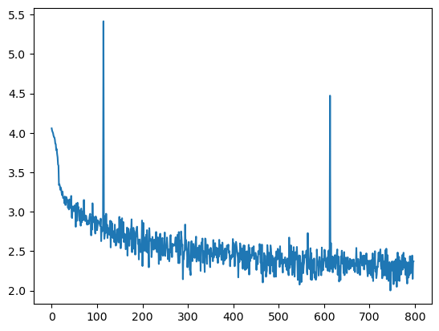

```python
import matplotlib.pyplot as plt
plt.plot(track_cost)
plt.show()
```

At this point, we can use the `sample` function we created earlier to explore some of the names we can generate. The code below provides a template for looking at various names that are generated from a given test letter.

```python
test_letter = 'Pr'
print('Korean:',sample('Korean', test_letter),
      '\nJapanese:', sample('Japanese', test_letter),
      '\nChinese:', sample('Chinese', test_letter),
      '\nEnglish:', sample('English', test_letter),
      '\nIrish:', sample('Irish', test_letter),
      '\nRussian:', sample('Russian', test_letter))
```

```
Korean: Prang
Japanese: Prakamamata
Chinese: Prang
English: Prareellen
Irish: Pranan
Russian: Provanovov
```

Notice that you can re-run the same commands several times and see slightly different results due to the dropout layer involved in the creation of the network's output.

**Question #6**: This question is also meant to be fun. Modify the `print` command given above to use a `test_letter` (seed character string) of your choice. Include your printed results, and provide 1-2 sentences commenting upon how you view the effectiveness of this model.

**Acknowledgements:** The contents of this lab were adapted from the following tutorials:

- https://pytorch.org/tutorials/intermediate/char_rnn_classification_tutorial.html
- https://pytorch.org/tutorials/beginner/former_torchies/nnft_tutorial.html